# 北京市中学生“体质体检”数据分析-肥胖程度（BMI）

```python
import IPython.core.display as di
#这部分程序将会在下方加一个按钮以选择是否隐藏代码
di.display_html('''<button onclick="jQuery('.input_area').toggle();jQuery('.prompt').toggle();">隐藏代码</button>''',raw=True)
```

本报告主要研究北京市初中生2017-2018“体质体检”所有数据中与学生“肥胖”相关的因素，报告共含 1）基础数据分析，2）直方图分析， 3)初步数据筛除， 4）分类数据处理， 5）空值处理， 6）数据标准化， 7）相关性分析， 8）两种体质测量标准对比分析， 9）肥胖、年龄、身高、体重综合分析， 10）PCA降维 共十个部分。

首先对数据字段缩写进行说明：

----------------体检----------------

- BMI-肥胖程度（S:偏瘦，M:正常，L: 超重, F:肥胖）
- Gender-性别（M：男，F：女）
- Age-年龄
- Class Grade-年级（7：初一，8：初二，9：初三）
- Height_Weight Grade-身高体重成绩
- r_hengya_1-恒牙患龋
- r_hengya_2-恒牙活动龋
- r_hengya_3-恒牙龋失
- r_hengya_4-恒牙龋补
- r_ruya_1-乳牙患龋
- r_ruya_2-乳牙活动龋
- r_ruya_3-乳牙龋失
- r_ruya_4-乳牙龋补
- r_xuehong-结果-血红蛋白（贫血）
- r_tizhong-结果-体重（40：上等， 50：中等， 60：下等）
- r_shengao-结果-身高（-1：年龄无标准，-2：身高无标准，10：上等， 20：中等，30：下等）
- shayan-沙眼
- sejue-色觉
- xinzang-心脏
- fei-肺
- ganpi-肝脾
- toujing-头颈
- jizhu-脊柱
- sizhi-四肢
- pifu-皮肤
- xiongbu-胸部
- jiemoyan-结膜炎
- xueya-血压
- xueya_one-血压1
- xueya_two-血压2
- xuehong-血红
- maibo-脉搏
- r_yingyang-结果-营养状况
- r_shili-结果-视力（910：正常， 920：边缘视力， 930：视力不良， 940：轻度视力不良，950：中度视力不良，960：重度视力不良）
- r_xueya-结果-血压
- r_yingyang_bmi-结果-营养bmi
- r_shengzhang-结果-生长发育
- r_maibo-结果-脉搏
- r_shili_last_year-结果-视力-上年度（910：正常， 920：边缘视力， 930：视力不良， 940：轻度视力不良，950：中度视力不良，960：重度视力不良）
- bmivalue-计算得到的BMI数值（bmivlaue=体重/身高,单位：kg/m^2）
- Final_Grade-最终成绩

----------------体质----------------

- Height-身高（单位：cm）
- Weight-体重（单位：kg）
- FeiHuoLiang-肺活量
- 50m-“50m”成绩（单位：秒）
- LiDingTiaoYuan-“立定跳远”成绩（单位：cm）
- ZuoWeiTiQianQu-“坐位体前屈”成绩（单位：cm）
- 800m-“800m”成绩（单位：分钟）
- 1km-“1km”成绩（单位：分钟）
- YangWoQiZuo-“仰卧起坐”成绩（单位：个数）
- YinTiXiangShang-“引体向上”成绩（单位：个数）
- luoyanyouyan-“裸眼右眼”视力
- luoyanzuoyan-“裸眼左眼”视力

```python
# 导入工具包
import pandas as pd
import matplotlib.pyplot as plt
import seaborn as sns
import numpy as np
```

## 一、基础数据分析

首先对“体质体检”数据作基础分析，了解基本构成：（下表仅显示部分数据）

```python
# 导入数据库
data = pd.read_csv("/Users/Administrator/Desktop/tztj_revised.csv")
df = pd.DataFrame(data)
data.head(10)
```

|  | BMI | Gender | Age | Class Grade | Height_Weight_Grade | r_hengya_1 | r_hengya_2 | r_hengya_3 | r_hengya_4 | r_hengya_5 | ... | FeiHuoLiang | 50m | LiDingTiaoYuan | ZuoWeiTiQianQu | 800m | 1km | YangWoQiZuo | YinTiXiangShang | luoyanyouyan | luoyanzuoyan |
| --- | --- | --- | --- | --- | --- | --- | --- | --- | --- | --- | --- | --- | --- | --- | --- | --- | --- | --- | --- | --- | --- |
| 0 | L | F | 13.0 | 8 | 80.0 | 1.0 | 0.0 | 0.0 | 0.0 | 2.0 | ... | 3210.0 | 8.60 | 184.0 | 20.0 | 3.46 | NaN | 49.0 | NaN | 4.1 | 4.4 |
| 1 | M | M | 14.0 | 8 | 100.0 | 1.0 | 0.0 | 0.0 | 0.0 | 2.0 | ... | 3112.0 | 7.60 | 209.0 | 15.0 | NaN | 3.34 | NaN | 11.0 | 4.4 | 4.4 |
| 2 | M | M | 13.0 | 8 | 100.0 | 1.0 | 0.0 | 0.0 | 0.0 | 2.0 | ... | 3025.0 | 7.50 | 222.0 | 15.0 | NaN | 3.41 | NaN | 0.0 | 5.0 | 4.9 |
| 3 | F | F | 13.0 | 8 | 60.0 | 1.0 | 0.0 | 0.0 | 0.0 | 2.0 | ... | 3174.0 | 9.47 | 160.0 | 18.0 | 3.48 | NaN | 47.0 | NaN | 4.5 | 4.6 |
| 4 | M | M | 13.0 | 8 | 100.0 | 2.0 | 1.0 | 0.0 | 0.0 | 2.0 | ... | 3438.0 | 7.80 | 204.0 | 7.0 | NaN | 4.18 | NaN | 0.0 | 4.3 | 4.2 |
| 5 | F | M | 13.0 | 8 | 60.0 | 1.0 | 0.0 | 0.0 | 0.0 | 2.0 | ... | 4043.0 | 8.00 | 170.0 | 5.0 | NaN | 4.24 | NaN | 0.0 | 5.0 | 5.0 |
| 6 | L | F | 14.0 | 8 | 80.0 | 1.0 | 0.0 | 0.0 | 0.0 | 2.0 | ... | 3093.0 | 10.30 | 155.0 | 4.0 | 3.53 | NaN | 50.0 | NaN | 4.1 | 4.1 |
| 7 | M | F | 13.0 | 8 | 100.0 | 2.0 | 1.0 | 0.0 | 0.0 | 2.0 | ... | 3351.0 | 8.19 | 190.0 | 17.0 | 3.17 | NaN | 60.0 | NaN | 5.0 | 5.0 |
| 8 | M | F | 13.0 | 8 | 100.0 | 1.0 | 0.0 | 0.0 | 0.0 | 2.0 | ... | 2511.0 | 10.04 | 150.0 | 14.0 | 4.02 | NaN | 38.0 | NaN | 4.0 | 4.0 |
| 9 | L | M | 13.0 | 8 | 80.0 | 1.0 | 0.0 | 0.0 | 0.0 | 2.0 | ... | 3094.0 | 7.40 | 180.0 | 9.0 | NaN | 3.57 | NaN | 0.0 | 4.8 | 4.7 |

10 rows × 54 columns

```python
# 基础数据信息
print("该数据库中含有 %d 个数据， 每个数据有 %d 个属性" %data.shape) #总数据量
```

```
该数据库中含有 265172 个数据， 每个数据有 54 个属性
```

“体质体检”数据中前10行的基础数据如上表所示。根据输出，该数据库中共265172个数据，每个数据有54个属性。

```python
data.describe() # 各属性基础统计分析
```

|  | Age | Class Grade | Height_Weight_Grade | r_hengya_1 | r_hengya_2 | r_hengya_3 | r_hengya_4 | r_hengya_5 | r_ruya_1 | r_ruya_2 | ... | FeiHuoLiang | 50m | LiDingTiaoYuan | ZuoWeiTiQianQu | 800m | 1km | YangWoQiZuo | YinTiXiangShang | luoyanyouyan | luoyanzuoyan |
| --- | --- | --- | --- | --- | --- | --- | --- | --- | --- | --- | --- | --- | --- | --- | --- | --- | --- | --- | --- | --- | --- |
| count | 241752.000000 | 265172.000000 | 249744.000000 | 242942.000000 | 242596.000000 | 242596.000000 | 242596.000000 | 196387.000000 | 242942.000000 | 242596.000000 | ... | 249744.000000 | 249744.000000 | 252824.000000 | 254175.000000 | 117282.000000 | 131307.000000 | 120458.000000 | 133717.000000 | 243926.000000 | 243926.000000 |
| mean | 13.112165 | 7.890192 | 90.106269 | 1.249150 | 0.238256 | 0.009089 | 0.248833 | 1.855133 | 1.001926 | 0.004209 | ... | 3020.962658 | 8.547133 | 180.737264 | 12.353111 | 3.764535 | 4.413729 | 40.746028 | 3.563892 | 4.599259 | 4.623724 |
| std | 1.022456 | 0.812937 | 15.028510 | 0.435878 | 0.728145 | 0.146533 | 0.778371 | 0.495591 | 0.069548 | 0.089580 | ... | 762.496405 | 1.012675 | 36.059923 | 7.461718 | 0.544836 | 0.831925 | 10.610696 | 4.873867 | 0.372682 | 0.372785 |
| min | 5.000000 | 7.000000 | 60.000000 | 0.000000 | 0.000000 | 0.000000 | 0.000000 | 0.000000 | 0.000000 | 0.000000 | ... | 500.000000 | 5.000000 | 0.000000 | -30.000000 | 2.010000 | 2.000000 | 0.000000 | 0.000000 | 0.000000 | 0.000000 |
| 25% | 12.000000 | 7.000000 | 80.000000 | 1.000000 | 0.000000 | 0.000000 | 0.000000 | 2.000000 | 1.000000 | 0.000000 | ... | 2488.000000 | 7.900000 | 165.000000 | 7.300000 | 3.360000 | 4.010000 | 35.000000 | 0.000000 | 4.300000 | 4.300000 |
| 50% | 13.000000 | 8.000000 | 100.000000 | 1.000000 | 0.000000 | 0.000000 | 0.000000 | 2.000000 | 1.000000 | 0.000000 | ... | 2934.000000 | 8.500000 | 180.000000 | 12.500000 | 3.530000 | 4.280000 | 42.000000 | 1.000000 | 4.600000 | 4.600000 |
| 75% | 14.000000 | 9.000000 | 100.000000 | 2.000000 | 0.000000 | 0.000000 | 0.000000 | 2.000000 | 1.000000 | 0.000000 | ... | 3474.000000 | 9.130000 | 200.000000 | 17.600000 | 4.140000 | 5.010000 | 48.000000 | 5.000000 | 5.000000 | 5.000000 |
| max | 22.000000 | 9.000000 | 100.000000 | 2.000000 | 16.000000 | 6.000000 | 16.000000 | 2.000000 | 2.000000 | 8.000000 | ... | 9800.000000 | 20.000000 | 360.000000 | 40.000000 | 9.000000 | 9.000000 | 87.000000 | 98.000000 | 5.300000 | 5.300000 |

8 rows × 52 columns

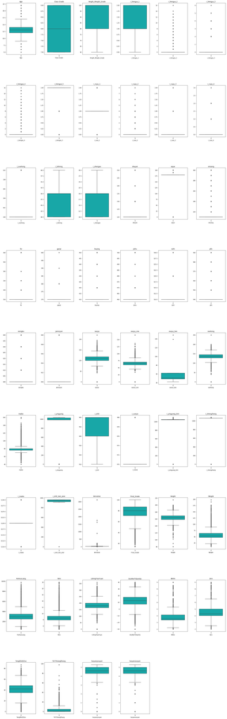

```python
# 绘制箱线图
fig=plt.figure(figsize=(30,100))
cols=6
rows=9
j=1
for i,column in enumerate(data.columns):
    if data.dtypes[column]!=np.object:
        ax=fig.add_subplot(rows,cols,j)
        ax.set_title(column)
        sns.boxplot(data=data[column],ax=ax,color='c')
        ax.set_xlabel(column)
        j=j+1
plt.subplots_adjust(hspace=0.6,wspace=0.3)
```

上图的箱线图主要包含五个数据节点，每一个“小箱子”代表数据从大到小排列共有5道横线，分别代表这组数据的 最大值（max），上四分位数（75%），中位数（50%），下四分位数（25%），最小值，图外的“小黑点”被认为是异常值（偏离大部分数据的点）。箱子内部涂色数据代表这组数据的25%-75%这一部分，因此箱子的宽度在一定程度上反映了数据的波动程度，由于它们受极值和异常值影响小，对比更具有代表性。

在上图中，大多数“体检”数据并没有形成内部涂色的“小箱子”，而只在下方形成一条直线，以及在上方有很多“小黑点”。这是因为：

1. 大多数“体检”数据是已经被处理过的结果数据，只含有几个特定离散的分数而不是连续的分数；
2. 大部分学生检查结果为正常，得到了统一的最低分，因此这组数据的最大值（max），上四分位数（75%），中位数（50%），下四分位数（25%），最小值都会是正常值，“小箱子”被压缩为一条直线。因此，下方形成的直线是代表数据量最大的正常值，而上方的“小黑点”代表其它可能出现的结果。

例如：对于“体检”数据中的“沙眼”（shayan），只含有120，130，140，150四种可能结果，由于大多数学生检查结果为正常，即得120分。这组数据的最大值（max），上四分位数（75%），中位数（50%），下四分位数（25%），最小值都出现在120，因此在箱线图的120分数形成一条直线，其它可能结果被认为是异常值，用“小黑点”表示了出来。

## 二、直方图分析

接着通过不同“肥胖程度”（S:偏瘦，M:正常，L: 超重, F:肥胖）在不同属性中的直方图分布情况，来判断“体质体检”数据的所有属性中与学生“肥胖”相关的因素。

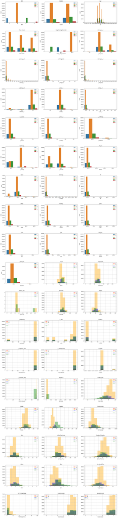

```python
#  直方图分析
fig=plt.figure(figsize=(24,120))
cols=3
rows=19
for i,column in enumerate(data.columns):
    ax=fig.add_subplot(rows,cols,i+1)
    ax.set_title(column)

    if i<28:
        sns.countplot(data[column],hue=data['BMI'],axes=ax)
        plt.legend(loc='upper right')

    else:
        l=['S','M','L','F']
        colors = ['r','orange','b','g']
        for i in range(4):
            data[data['BMI']==l[i]][column].hist(alpha=0.4,axes=ax,label=l[i],color=colors[i])
        #data.groupby('BMI')[column].hist(alpha=0.4,axes=ax)
        plt.legend(loc='best')
        ax.set_xlabel(column)

plt.subplots_adjust(hspace=0.4,wspace=0.2)
```

猜测：（以下仅为根据初步数据分析得到的猜测，具体相关程度的判定将会在下面几个部分中进行）

1. 性别：男生肥胖率明显高于女生，女生正常体重比例高于男生=〉男生易发胖
2. 身高：肥胖程度不同的的学生身高分布无明显差异 =〉肥胖的学生身高与正常/偏瘦学生的身高不会有太大区别
3. 体重：肥胖程度不同的的学生体重分布出现明显的分离，肥胖学生体重明显高于正常学生， 正常学生体重稍高于偏瘦学生 =〉对中学生来说，肥胖程度更多的取决于体重，而不是身高
4. 血压：相对于正常学生，肥胖或体重偏高的学生血压偏高=〉“血压”，“血压1”和“血压2”均出现此现象，但不清楚相对较高的血压是否仍在正常范围内
5. 体检总成绩：体重偏低，体重偏高，肥胖的学生总成绩均低于正常学生；相比于体重偏低 或体重偏高的学生，肥胖学生总体体检成绩最低=〉1.）肥胖这一项的得分降低了体检总成绩得分；2.）肥胖的学生其它方面体检成绩也会偏低
6. 肺活量：体重偏低学生，肺活量偏低，其它无明显差异=〉体重影响肺活量，在较低体重影响更明显
7. 50m：肥胖学生50m成绩偏低，其它无明显差异=〉肥胖影响爆发力，反应能力
8. 立定跳远:体重偏低，体重偏高，肥胖的学生立定跳远成绩均低于正常学生=〉肥胖/偏瘦影响弹跳能力
9. 坐位体前屈：无明显差异=〉肥胖并不影响身体的柔软程度
10. 800m，1km：肥胖学生长跑成绩明显低于正常学生，体重偏高长跑成绩略低于正常学生，偏瘦学生与正常学生相同=〉肥胖影响耐力
11. 引体向上：无明显差异，但是无论是体重正常，偏低或肥胖的学生，引体向上个数普遍不超过10个=〉北京市中学生上半身力量训练不足，普遍偏弱

总结：

- 对于大部分直方图来说，不同“肥胖程度”（即不同颜色）的直方图在同一属性里的分布非常相似，表明不同的“肥胖程度”并不影响它在此属性中的分布。我们可以大致认为这部分属性与初中学生的“肥胖程度”是没有关系的。例如：“性别”（Gender），年龄（Age）。
- 对于小部分直方图，不同“肥胖程度”（即不同颜色）的直方图在同一属性的分布存在差异，表明不同的“肥胖程度”对它在此属性中的分布存在某种影响/关联关系。我们可以先假设这部分属性与初中学生的“肥胖程度”存在某些联系，并在接下来将对这些属性与“肥胖程度”的相关性进行着重分析。这一小部分属性包括： “身高体重成绩”（Height_Weight_Grade）, “血压”（xueya）, “血压2”（xueya_two）, “血红”（xuehong）, “脉搏”（maibo）, “计算得到的BMI数值”（bmivalue）,“最终成绩”（ Final_Grade）,“体重”( Weight), “立定跳远”（LiDingTiaoYuan）, “800m”, “1km”,和 “仰卧起坐”（YangWoQiZuo）。
- 由于前缀为“r”的属性为后期计算属性，而不是初始数据，这部分数据不具有代表性；而且会与原始数据的作用相重合，为防止“过拟合”现象出现，在接下来的分析过程中会筛除这部分数据。例如：“结果-身高”（r_shengao）,“结果-体重”（r_tizhong）。

## 三、初步属性筛除

通过第一、二部分对“体质体检”数据的初步分析， 我们可以筛除部分与“肥胖程度”不相关的属性（例如：“性别”（Gender），年龄（Age））和一部分不具有代表性的属性（前缀为“r”的属性，如“结果-身高”（r_shengao）,“结果-体重”（r_tizhong））。

在筛除这部分属性后，余下数据及属性如下表所示：

```
 *注意：由于在第八部分要进行不同营养计算标准的比较，所以没有删除“结果-营养状况”（r_yingyang）和“结果-营养bmi”（r_yingyang_bmi）这两个以“ r”为前缀的属性。
```

```python
data_reduced=data[['BMI','bmivalue','Gender','Weight','Height','shayan','sejue','xinzang','fei','ganpi','toujing','jizhu','sizhi','pifu','xiongbu','jiemoyan','xueya','xueya_one','xueya_two','xuehong','maibo','luoyanzuoyan','luoyanyouyan','Final_Grade','FeiHuoLiang','50m','LiDingTiaoYuan','ZuoWeiTiQianQu','1km','YangWoQiZuo','YinTiXiangShang','r_yingyang','r_yingyang_bmi']]
data_reduced.head()
```

|  | BMI | bmivalue | Gender | Weight | Height | shayan | sejue | xinzang | fei | ganpi | ... | Final_Grade | FeiHuoLiang | 50m | LiDingTiaoYuan | ZuoWeiTiQianQu | 1km | YangWoQiZuo | YinTiXiangShang | r_yingyang | r_yingyang_bmi |
| --- | --- | --- | --- | --- | --- | --- | --- | --- | --- | --- | --- | --- | --- | --- | --- | --- | --- | --- | --- | --- | --- |
| 0 | L | 23.53 | F | 61.6 | 161.8 | 120.0 | NaN | 210.0 | 310.0 | 370.0 | ... | 87.0 | 3210.0 | 8.60 | 184.0 | 20.0 | NaN | 49.0 | NaN | 1040.0 | 1050.0 |
| 1 | M | 18.48 | M | 47.9 | 161.0 | 120.0 | NaN | 210.0 | 310.0 | 370.0 | ... | 91.0 | 3112.0 | 7.60 | 209.0 | 15.0 | 3.34 | NaN | 11.0 | 985.0 | 1045.0 |
| 2 | M | 18.55 | M | 50.2 | 164.5 | 120.0 | NaN | 210.0 | 310.0 | 370.0 | ... | 83.0 | 3025.0 | 7.50 | 222.0 | 15.0 | 3.41 | NaN | 0.0 | 985.0 | 1045.0 |
| 3 | F | 29.76 | F | 82.4 | 166.4 | 120.0 | NaN | 210.0 | 310.0 | 370.0 | ... | 80.0 | 3174.0 | 9.47 | 160.0 | 18.0 | NaN | 47.0 | NaN | 1040.0 | 1060.0 |
| 4 | M | 16.27 | M | 47.3 | 170.5 | 120.0 | NaN | 210.0 | 310.0 | 370.0 | ... | 74.0 | 3438.0 | 7.80 | 204.0 | 7.0 | 4.18 | NaN | 0.0 | 990.0 | 1045.0 |

5 rows × 33 columns

经过初步属性筛除，共余下33个属性。更新后的数据如上表所示（仅显示前5行数据）。由于缺失值（空值）会影响相关系数的计算，接下来寻找余下属性中的缺失值。

下表与上表为一一对应关系，其中只含有“True”和“False”两个值，其中“True”表示该位置为空值，“False”表示该位置不是空值。

```python
# 数据缺失值定位
data_reduced.isnull().head()
```

|  | BMI | bmivalue | Gender | Weight | Height | shayan | sejue | xinzang | fei | ganpi | ... | Final_Grade | FeiHuoLiang | 50m | LiDingTiaoYuan | ZuoWeiTiQianQu | 1km | YangWoQiZuo | YinTiXiangShang | r_yingyang | r_yingyang_bmi |
| --- | --- | --- | --- | --- | --- | --- | --- | --- | --- | --- | --- | --- | --- | --- | --- | --- | --- | --- | --- | --- | --- |
| 0 | False | False | False | False | False | False | True | False | False | False | ... | False | False | False | False | False | True | False | True | False | False |
| 1 | False | False | False | False | False | False | True | False | False | False | ... | False | False | False | False | False | False | True | False | False | False |
| 2 | False | False | False | False | False | False | True | False | False | False | ... | False | False | False | False | False | False | True | False | False | False |
| 3 | False | False | False | False | False | False | True | False | False | False | ... | False | False | False | False | False | True | False | True | False | False |
| 4 | False | False | False | False | False | False | True | False | False | False | ... | False | False | False | False | False | False | True | False | False | False |

5 rows × 33 columns

为了更好地了解各个属性的空值情况，将各属性的“总缺失数据”和“缺失数据占比”（缺失数据数目占总数据的数目的比例）总结在下表中。可以看出，“血压2”（xueya_two），“脉搏”(maibo)，“仰卧起坐”(YangWoQiZuo)，“色觉”(sejue)，“血压”(xueya)，“血压1”(xueya_one)，“1km”，“ 引体向上”(YinTiXiangShang)，和“结膜炎”(jiemoyan)这9个属性的缺失数据占比都超过或接近50%，以为这这些属性有近一半的数值缺失，为空值。在计算与“肥胖程度”的相关系数前需要先处理这些缺失项。

```python
# 数据缺失信息汇总
#missing data
total = data_reduced.isnull().sum().sort_values(ascending=False)
percent = (data_reduced.isnull().sum()/data.shape[0]).sort_values(ascending=False)
missing_data = pd.concat([total, percent], axis=1, keys=['总缺失数据', '缺失数据占比'])
missing_data.head(20)
```

|  | 总缺失数据 | 缺失数据占比 |
| --- | --- | --- |
| xueya_two | 265160 | 0.999955 |
| maibo | 194074 | 0.731880 |
| YangWoQiZuo | 144714 | 0.545736 |
| sejue | 144705 | 0.545702 |
| xueya | 143259 | 0.540249 |
| xueya_one | 143259 | 0.540249 |
| 1km | 133865 | 0.504823 |
| YinTiXiangShang | 131455 | 0.495735 |
| jiemoyan | 118680 | 0.447559 |
| pifu | 29757 | 0.112218 |
| xiongbu | 23380 | 0.088169 |
| shayan | 23310 | 0.087905 |
| sizhi | 21959 | 0.082810 |
| xinzang | 21860 | 0.082437 |
| xuehong | 21787 | 0.082162 |
| ganpi | 21439 | 0.080849 |
| fei | 21428 | 0.080808 |
| toujing | 21416 | 0.080763 |
| jizhu | 21357 | 0.080540 |
| luoyanyouyan | 21246 | 0.080122 |

## 四、分类数据处理

将属性“BMI”和“性别”（Gender）的所有分类数据转化为数值，方便计算。转化后数据更新如下（仅显示前5行）：

```python
data_reduced.loc[data_reduced['BMI']=='S','BMI']=1.0
data_reduced.loc[data_reduced['BMI']=='M','BMI']=2.0
data_reduced.loc[data_reduced['BMI']=='L','BMI']=3.0
data_reduced.loc[data_reduced['BMI']=='F','BMI']=4.0
data_reduced.loc[data_reduced['Gender']=='F','Gender']=1.0
data_reduced.loc[data_reduced['Gender']=='M','Gender']=2.0
data_reduced.head()
```

[output not shown]

|  | BMI | bmivalue | Gender | Weight | Height | shayan | sejue | xinzang | fei | ganpi | ... | Final_Grade | FeiHuoLiang | 50m | LiDingTiaoYuan | ZuoWeiTiQianQu | 1km | YangWoQiZuo | YinTiXiangShang | r_yingyang | r_yingyang_bmi |
| --- | --- | --- | --- | --- | --- | --- | --- | --- | --- | --- | --- | --- | --- | --- | --- | --- | --- | --- | --- | --- | --- |
| 0 | 3 | 23.53 | 1 | 61.6 | 161.8 | 120.0 | NaN | 210.0 | 310.0 | 370.0 | ... | 87.0 | 3210.0 | 8.60 | 184.0 | 20.0 | NaN | 49.0 | NaN | 1040.0 | 1050.0 |
| 1 | 2 | 18.48 | 2 | 47.9 | 161.0 | 120.0 | NaN | 210.0 | 310.0 | 370.0 | ... | 91.0 | 3112.0 | 7.60 | 209.0 | 15.0 | 3.34 | NaN | 11.0 | 985.0 | 1045.0 |
| 2 | 2 | 18.55 | 2 | 50.2 | 164.5 | 120.0 | NaN | 210.0 | 310.0 | 370.0 | ... | 83.0 | 3025.0 | 7.50 | 222.0 | 15.0 | 3.41 | NaN | 0.0 | 985.0 | 1045.0 |
| 3 | 4 | 29.76 | 1 | 82.4 | 166.4 | 120.0 | NaN | 210.0 | 310.0 | 370.0 | ... | 80.0 | 3174.0 | 9.47 | 160.0 | 18.0 | NaN | 47.0 | NaN | 1040.0 | 1060.0 |
| 4 | 2 | 16.27 | 2 | 47.3 | 170.5 | 120.0 | NaN | 210.0 | 310.0 | 370.0 | ... | 74.0 | 3438.0 | 7.80 | 204.0 | 7.0 | 4.18 | NaN | 0.0 | 990.0 | 1045.0 |

5 rows × 33 columns

## 五、空值（缺失值）处理

处理空值（缺失值），处理后后数据更新如下（仅显示前5行）：

```python
# 删除“性别”和“BMI”中空值的那一行
data_reduced=data_reduced.dropna(subset = ['Gender'])
data_reduced=data_reduced.dropna(subset = ['BMI'])
data_reduced=data_reduced.dropna(subset = ['bmivalue'])
del data_reduced['xueya_two']
```

```python
#mean imputation
#axis = 0,表示列向，采用每一列的平均值填补空值
from sklearn.preprocessing import Imputer
imr = Imputer(missing_values = 'NaN', strategy = 'mean', axis = 0 )
imr = imr.fit(data_reduced.values)
imputed_data = imr.transform(data_reduced.values)
imputed_data=pd.DataFrame(imputed_data)
imputed_data.columns=[['BMI','bmivalue','Gender','Weight','Height','shayan','sejue','xinzang','fei','ganpi','toujing','jizhu','sizhi','pifu','xiongbu','jiemoyan','xueya','xueya_one','xuehong','maibo','luoyanzuoyan','luoyanyouyan','Final_Grade','FeiHuoLiang','50m','LiDingTiaoYuan','ZuoWeiTiQianQu','1km','YangWoQiZuo','YinTiXiangShang','r_yingyang','r_yingyang_bmi']]
```

```python
imputed_data.head()
```

|  | BMI | bmivalue | Gender | Weight | Height | shayan | sejue | xinzang | fei | ganpi | ... | Final_Grade | FeiHuoLiang | 50m | LiDingTiaoYuan | ZuoWeiTiQianQu | 1km | YangWoQiZuo | YinTiXiangShang | r_yingyang | r_yingyang_bmi |
| --- | --- | --- | --- | --- | --- | --- | --- | --- | --- | --- | --- | --- | --- | --- | --- | --- | --- | --- | --- | --- | --- |
| 0 | 3.0 | 23.53 | 1.0 | 61.6 | 161.8 | 120.0 | 160.061175 | 210.0 | 310.0 | 370.0 | ... | 87.0 | 3210.0 | 8.60 | 184.0 | 20.0 | 4.421752 | 49.000000 | 3.498113 | 1040.0 | 1050.0 |
| 1 | 2.0 | 18.48 | 2.0 | 47.9 | 161.0 | 120.0 | 160.061175 | 210.0 | 310.0 | 370.0 | ... | 91.0 | 3112.0 | 7.60 | 209.0 | 15.0 | 3.340000 | 41.535056 | 11.000000 | 985.0 | 1045.0 |
| 2 | 2.0 | 18.55 | 2.0 | 50.2 | 164.5 | 120.0 | 160.061175 | 210.0 | 310.0 | 370.0 | ... | 83.0 | 3025.0 | 7.50 | 222.0 | 15.0 | 3.410000 | 41.535056 | 0.000000 | 985.0 | 1045.0 |
| 3 | 4.0 | 29.76 | 1.0 | 82.4 | 166.4 | 120.0 | 160.061175 | 210.0 | 310.0 | 370.0 | ... | 80.0 | 3174.0 | 9.47 | 160.0 | 18.0 | 4.421752 | 47.000000 | 3.498113 | 1040.0 | 1060.0 |
| 4 | 2.0 | 16.27 | 2.0 | 47.3 | 170.5 | 120.0 | 160.061175 | 210.0 | 310.0 | 370.0 | ... | 74.0 | 3438.0 | 7.80 | 204.0 | 7.0 | 4.180000 | 41.535056 | 0.000000 | 990.0 | 1045.0 |

5 rows × 32 columns

## 六、数据标准化

在多属性评价体系中，由于各属性具有不同的量纲和数量级。当各属性间的水平相差很大时，如果直接用原始属性数据值进行分析，就会突出数值较高的属性在综合分析中的作用，相对削弱数值水平较低属性的作用。因此，为了保证结果的可靠性，需要对原始数据进行标准化处理。

将各个属性的数据标准化为均值为0，方差为1的分布，标准化后数据更新如下（仅显示前5行）：

```python
#sklearn standardization将数据标准化为均值为0 方差为1
from sklearn.preprocessing import StandardScaler
stdsc = StandardScaler()
imputed_data_std = stdsc.fit_transform(imputed_data)
```

```python
imputed_data_std=pd.DataFrame(imputed_data_std)
imputed_data_std.columns=[['BMI','bmivalue','Gender','Weight','Height','shayan','sejue','xinzang','fei','ganpi','toujing','jizhu','sizhi','pifu','xiongbu','jiemoyan','xueya','xueya_one','xuehong','maibo','luoyanzuoyan','luoyanyouyan','Final_Grade','FeiHuoLiang','50m','LiDingTiaoYuan','ZuoWeiTiQianQu','1km','YangWoQiZuo','YinTiXiangShang','r_yingyang','r_yingyang_bmi']]
imputed_data_std.head()
```

|  | BMI | bmivalue | Gender | Weight | Height | shayan | sejue | xinzang | fei | ganpi | ... | Final_Grade | FeiHuoLiang | 50m | LiDingTiaoYuan | ZuoWeiTiQianQu | 1km | YangWoQiZuo | YinTiXiangShang | r_yingyang | r_yingyang_bmi |
| --- | --- | --- | --- | --- | --- | --- | --- | --- | --- | --- | --- | --- | --- | --- | --- | --- | --- | --- | --- | --- | --- |
| 0 | 0.715157 | 0.247918 | -1.052727 | 0.346226 | -0.241773 | -0.023075 | 1.416051e-15 | -0.063612 | -0.011311 | -0.006682 | ... | 0.754734 | 0.252734 | 0.055916 | 0.008868 | 1.010699 | 0.000000 | 1.173365 | 0.000000 | 0.474097 | 0.078518 |
| 1 | -0.541292 | -0.292984 | 0.949914 | -0.618722 | -0.339138 | -0.023075 | 1.416051e-15 | -0.063612 | -0.011311 | -0.006682 | ... | 1.099455 | 0.124166 | -0.937334 | 0.937169 | 0.330280 | -1.795166 | 0.000000 | 2.153400 | 0.307214 | 0.023422 |
| 2 | -0.541292 | -0.285486 | 0.949914 | -0.456723 | 0.086833 | -0.023075 | 1.416051e-15 | -0.063612 | -0.011311 | -0.006682 | ... | 0.410013 | 0.010030 | -1.036659 | 1.419886 | 0.330280 | -1.679001 | 0.000000 | -1.004125 | 0.307214 | 0.023422 |
| 3 | 1.971606 | 0.915209 | -1.052727 | 1.811256 | 0.318074 | -0.023075 | 1.416051e-15 | -0.063612 | -0.011311 | -0.006682 | ... | 0.151472 | 0.205505 | 0.920044 | -0.882302 | 0.738531 | 0.000000 | 0.858998 | 0.000000 | 0.474097 | 0.188710 |
| 4 | -0.541292 | -0.529696 | 0.949914 | -0.660982 | 0.817068 | -0.023075 | 1.416051e-15 | -0.063612 | -0.011311 | -0.006682 | ... | -0.365609 | 0.551850 | -0.738684 | 0.751509 | -0.758389 | -0.401187 | 0.000000 | -1.004125 | 0.322385 | 0.023422 |

5 rows × 32 columns

## 七、相关性分析及显著性检验

基础数据处理结束，计算“肥胖程度”（BMI）与各个属性间的相关系数。通过相关系数来反应不同属性与“肥胖程度”之间的线性相关程度。

其中，正数代表正相关，负数代表负相关。相关系数的绝对值越大，相关性越强：相关系数越接近于1或-1，相关度越强，相关系数越接近于0，相关度越弱。 通常情况下通过以下取值范围判断变量的相关强度：

- 0.8-1.0 极强相关
- 0.6-0.8 强相关
- 0.4-0.6 中等程度相关
- 0.2-0.4 弱相关
- 0.0-0.2 极弱相关或无相关

### 1）相关系数

首先先对所有属性间的相关关系做一个基础了解， 下图是所有属性间相关系数的总结图：

- 每一行与每一列的交叉的单元格表示这两个属性的相关系数，单元格颜色代表系数大小
- 由于对角线是属性自己与自己的相关系数，所以对角线上的系数永远为1
- 该图关于对角线对称

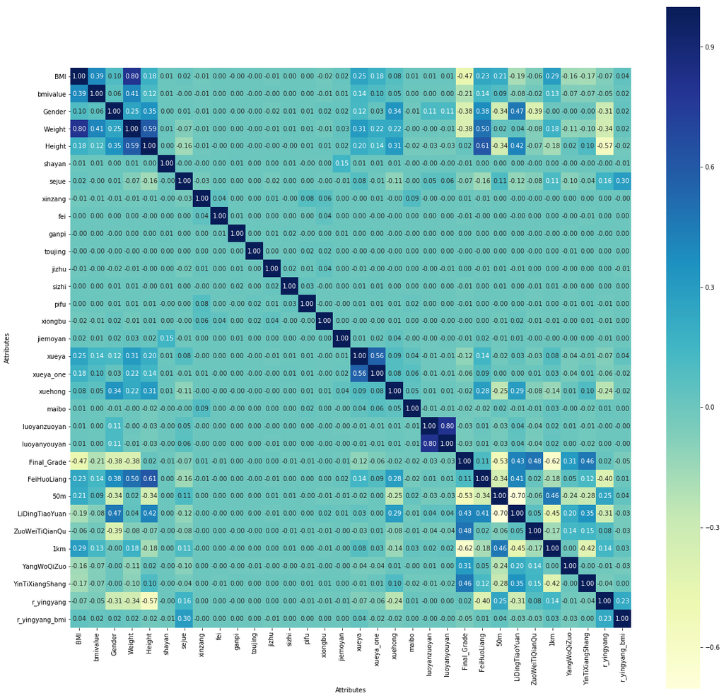

```python
# 相关性分析
corr=imputed_data_std.corr()
#correlation matrix
f, ax = plt.subplots(figsize=(20,20))
sns.heatmap(corr, cmap='YlGnBu',annot=True,square=True,fmt='.2f');
plt.xlabel('Attributes');
plt.ylabel('Attributes');
```

在上图中，颜色最深和颜色最浅的单元格代表相关系数的绝对值越大，因此可以发现相关程度较高的几个属性主要集中在前5个“体检属性”和后面的“体质属性”。

为了更加直观清晰地展示“肥胖程度”与其它各个属性间的相关关系，现将“肥胖程度”的那一行单独表示出来：

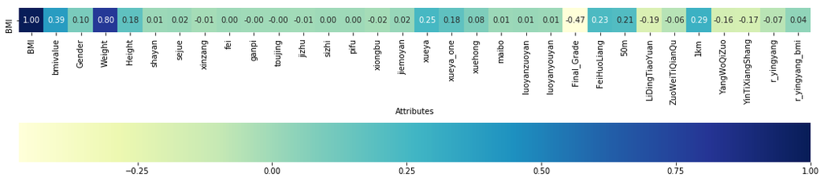

```python
#corr[:1][:]
plt.subplots(figsize=(18,14))
sns.heatmap(corr[:1][:], cmap='YlGnBu',annot=True,square=True,fmt='.2f', cbar_kws={"orientation": "horizontal"});
plt.xlabel('Attributes');
plt.ylabel('');
```

从上图中可以看出，除了“肥胖程度”（BMI）与自身的相关系数为1外， 与“体重”（Weight） 有强相关关系， 与“bmi数值”（bmivalue），“身高”（Height），“血压”（xueya），“血压1”（xueya_one），“体检最终成绩”（Final_Grade），“肺活量”（FeiHuoLiang），“50m”，“立定跳远”（LiDingTiaoYuan），“1km”，“仰卧起坐”（YangWoQiZuo）之间都存在一定程度的相关，而与其它属性可以认为不存在相关关系。这与第二部分“直方图分析”中的猜测是相一致的，可以作为猜测的一个支持论据。

### 2）显著性检验

在对实际现象进行分析时，往往是利用样本数据计算相关系数作为总体相关系数的估计值，但由于样本相关系数具有一定的随机性，它能否说明总体的相关程度往往同样本容量有一定关系。当样本容量很小时，计算出的相关系数不一定能反映总体的真实相关关系，而且，当总体不相关时，利用样本数据计算出的也不一定等于零，有时还可能较大，这就会产生虚假相关现象。为判断样本相关系数对总体相关程度的代表性，需要对相关系数进行显著性检验。

若在统计上是显著的，说明它可以作为总体相关程度的代表值，否则不能作为总体相关程度的代表值。检验结果的p值越小表明两个变量相关性越大，为0表示显著相关，<0.05表示相关性大，为1表示基本不相关。

由于“体质体检”数据的样本量很大，大约含有26万个数据，实际出现虚假相关现象的可能性很小。但是为了通过样本相关系数判断总体中是否也存在同样的相关关系，接下来对每个相关系数进行显著性检验，计算p值。

```python
# 各个相关系数的显著性检验
import scipy.stats as stats
correlation=[]
pvalue=[]
for i in range(len(imputed_data_std.columns)):
    x=imputed_data_std['BMI']
    y=imputed_data_std.iloc[:,i:i+1]
    r,p=stats.pearsonr(x,y)
    correlation.append(float(r))
    pvalue.append(float(p))
```

```python
# 把相关系数和p值总结到一个表格中
cp = { 'corr': correlation,'p值':pvalue}
dcp = pd.DataFrame(data=cp)
dcp.index=imputed_data_std.columns
dcp.transpose()
```

|  | BMI | bmivalue | Gender | Weight | Height | shayan | sejue | xinzang | fei | ganpi | ... | Final_Grade | FeiHuoLiang | 50m | LiDingTiaoYuan | ZuoWeiTiQianQu | 1km | YangWoQiZuo | YinTiXiangShang | r_yingyang | r_yingyang_bmi |
| --- | --- | --- | --- | --- | --- | --- | --- | --- | --- | --- | --- | --- | --- | --- | --- | --- | --- | --- | --- | --- | --- |
| corr | 1.0 | 0.392045 | 0.096916 | 0.798435 | 0.176236 | 0.008326 | 1.689054e-02 | -1.235331e-02 | 0.002916 | -0.001516 | ... | -0.470146 | 0.231147 | 0.2141 | -0.189082 | -6.054411e-02 | 0.290919 | -0.160302 | -0.171037 | -6.586348e-02 | 3.565400e-02 |
| p值 | 0.0 | 0.000000 | 0.000000 | 0.000000 | 0.000000 | 0.000046 | 1.369630e-16 | 1.481799e-09 | 0.153548 | 0.458048 | ... | 0.000000 | 0.000000 | 0.0000 | 0.000000 | 2.563983e-193 | 0.000000 | 0.000000 | 0.000000 | 1.801663e-228 | 3.112472e-68 |

2 rows × 32 columns

每个属性与“肥胖程度”的“相关系数”（corr）与“p值”如上表所示，下方的热力图更清楚直观的展示了它们之间的大小关系：

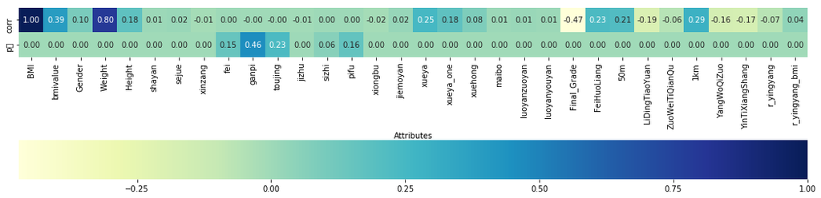

```python
plt.subplots(figsize=(18,13))
sns.heatmap(dcp.transpose(), cmap='YlGnBu',annot=True,square=True,fmt='.2f',cbar_kws={"orientation": "horizontal"});
plt.xlabel('Attributes');
```

通过上方的热力图可以看出，所有与“肥胖程度”（BMI）存在一定程度的相关的属性：“体重”（Weight），“bmi数值”（bmivalue），“身高”（Height），“血压”（xueya），“血压1”（xueya_one），“体检最终成绩”（Final_Grade），“肺活量”（FeiHuoLiang），“50m”，“立定跳远”（LiDingTiaoYuan），“1km”，“仰卧起坐”（YangWoQiZuo）计算出的p值均为0， 这说明“肥胖程度”与这些属性之间的相关程度是显著的，均通过显著性检验。

## 八、两种体质测量标准对比分析—肥胖程度（BMI）和营养 (r_yingyang&r_yingyang_bmi)

在所提供的“体质体检”数据中，存在“营养状况”（r_yingyang）和“营养bmi”（r_yingyang_bmi）两个不同的反应学生营养水平的标准。

通过下方的热力图可以看出：

- “营养状况”（r_yingyang）和“营养bmi”（r_yingyang_bmi）之间的相关系数为0.23，而这之间存在某种程度上的相关关系=〉“营养状况”（r_yingyang）和“营养bmi”（r_yingyang_bmi）确实都反应了学生的营养水平
- 对比“营养状况”（r_yingyang）和“营养bmi”（r_yingyang_bmi）与其它属性间的相关系数， 可以看出它们分别与不同的属性相关联=〉“营养状况”（r_yingyang）和“营养bmi”（r_yingyang_bmi）是通过不同的方面来反应学生的营养水平的

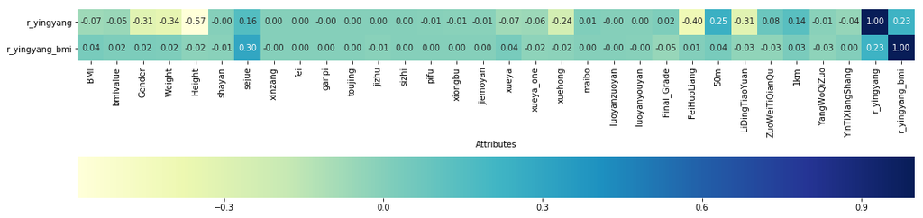

```python
plt.subplots(figsize=(18,14))
sns.heatmap(corr[-2:][:], cmap='YlGnBu',annot=True,square=True,fmt='.2f', cbar_kws={"orientation": "horizontal"});
plt.xlabel('Attributes');
plt.ylabel('');
```

在“体质体检”数据中，“营养”作为另一个反应学生体质的标准，与“肥胖程度”的标准之间是否存在相关关系，是这一部分将要分析的重点。

```python
#单独提取所需数据
data_comp = data_reduced[['BMI','bmivalue','r_yingyang','r_yingyang_bmi']]
data_comp['bmi_index']=data_reduced['BMI']
data_comp.loc[data_comp['BMI']==1,'bmi_index']='S'
data_comp.loc[data_comp['BMI']==2,'bmi_index']='M'
data_comp.loc[data_comp['BMI']==3,'bmi_index']='L'
data_comp.loc[data_comp['BMI']==4,'bmi_index']='F'
```

[output not shown]

首先绘制绘制bmi与 “营养状况”之间的散点图：

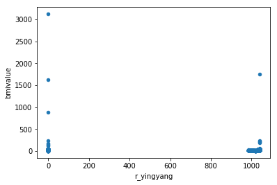

```python
#绘制bmi与 “营养状况”之间的散点图
data_comp.plot.scatter(y='bmivalue', x='r_yingyang');
plt.figure(figsize=(100,100));
```

从上图可以看出数据两级分化严重，并存在极端数据（怀疑为错误值）。一般认为认为正常人的bmi值不会超过50，超过50的值被认为是异常值，所以下面找一下这些异常值的大致数量：

```python
# 寻找bmivalue超过50的数据量
check1=data[data['bmivalue']>50]
print("bmi大于50的数据数量为：%d"%max(check1.count()))
```

```
bmi大于50的数据数量为：25
```

```python
check1[['BMI','bmivalue','r_yingyang','r_yingyang_bmi','Height','Weight']].head()
```

|  | BMI | bmivalue | r_yingyang | r_yingyang_bmi | Height | Weight |
| --- | --- | --- | --- | --- | --- | --- |
| 28317 | M | 58.59 | -2.0 | 1070.0 | 167.0 | 59.0 |
| 53194 | M | 215.56 | 1040.0 | 1060.0 | 145.3 | 39.5 |
| 61974 | F | 51.14 | 1040.0 | 1060.0 | 162.4 | 137.6 |
| 62690 | M | 889.60 | -2.0 | 1070.0 | 161.0 | 45.0 |
| 65039 | F | 62.71 | 1040.0 | 1070.0 | 174.6 | 105.0 |

上表显示了部分bmi大于50的数据，根据输出结果可以认为：“体质体检”统计结果中存在错误数据，27万个数据中至少存在25个矛盾数据（以bmivalue=50为上限）

下面对bmi和两个营养测量属性进行初步的分析，看看它们的平均水平和离散程度：

```python
data_comp.describe()
```

|  | bmivalue | r_yingyang | r_yingyang_bmi |
| --- | --- | --- | --- |
| count | 239546.000000 | 239546.000000 | 239546.000000 |
| mean | 21.215375 | 883.750415 | 1042.874475 |
| std | 9.336279 | 329.574020 | 90.750827 |
| min | 0.000000 | -2.000000 | -1.000000 |
| 25% | 17.980000 | 985.000000 | 1045.000000 |
| 50% | 20.180000 | 985.000000 | 1045.000000 |
| 75% | 23.540000 | 1030.000000 | 1050.000000 |
| max | 3123.140000 | 1040.000000 | 1100.000000 |

上表显示了bmi和两个营养测量属性数据量，平均值，标准差，最大，最小，25%，中值，75%等基本信息。

### 1) bmivalue和r_yingyang

首先假定认为bmi在0-50之间为正确数据，在不进行任何处理的情况下看二者之间的数据分布:

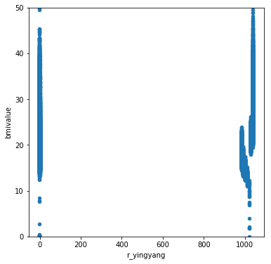

```python
# 首先假定认为bmi在0-50之间为正确数据，在不进行任何处理的情况下看二者之间的数据分布
data_comp.plot.scatter(y='bmivalue', x='r_yingyang',ylim=(0,50),figsize=(6,6));
```

从上图可以看出“营养状况”的数据基本集中在0和1000两个数据周围呈离散分布，“bmi数值”与“营养状况”间基本不存在线性关系。为了更加直观的判断与“肥胖程度”的关系，对上图的点进行颜色分类:“红色”代表“偏瘦”，“橙色”代表“正常”，“蓝色”代表“偏胖”，“绿色”代表“肥胖”。

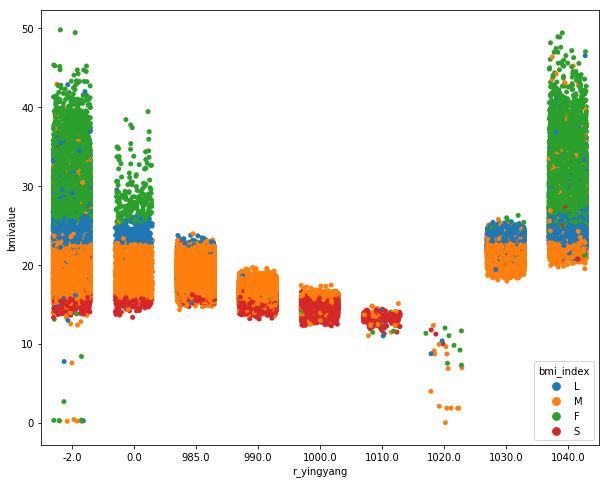

```python
# 假定认为bmi在0-50之间为正确数据
data_comp=data_comp[data_comp['bmivalue']<50][['r_yingyang','r_yingyang_bmi','bmivalue','BMI','bmi_index']]
plt.figure(figsize=(10,8));
sns.stripplot(y='bmivalue',x='r_yingyang',hue='bmi_index',data=data_comp,jitter=0.3);
```

从上图可以很清楚的看出，对于“营养状况”测量标准：

1. 肥胖的学生（绿色的点）主要集中在“营养状况”的两侧极值区域：-2和1040周围;
2. 偏瘦的学生（红色的点）主要集中在“营养状况”的中心区域：1000周围

这说明虽然“营养状况”的每个取值都存在不同“肥胖程度”的学生，但是在一些特定取值处某类“肥胖程度”的学生数会占据大量比例=〉说明“营养状况”（r_yingyang）和“肥胖程度”（BMI）之间虽然没有线性相关关系，但仍存在某种对应联系。

### 2) bmivalue和r_yingyang_bmi

首先假定认为bmi在0-50之间为正确数据，在不进行任何处理的情况下看二者之间的数据分布：

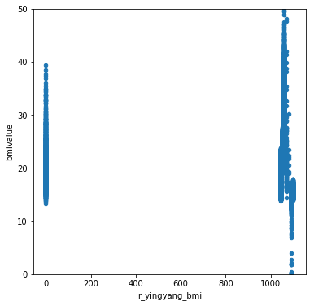

```python
#首先假定认为bmi在0-50之间为正确数据，在不进行任何处理的情况下看二者之间的数据分布
data_comp.plot.scatter(y='bmivalue', x='r_yingyang_bmi',ylim=(0,50),figsize=(6,6));
```

从上图可以看出“营养bmi”的数据基本集中在0和1000两个数据周围呈离散分布，“bmi数值”与“营养bmi”间基本不存在线性关系。为了更加直观的判断它与“肥胖程度”的关系，对上图的点进行颜色分类:“红色”代表“偏瘦”，“橙色”代表“正常”，“蓝色”代表“偏胖”，“绿色”代表“肥胖”。

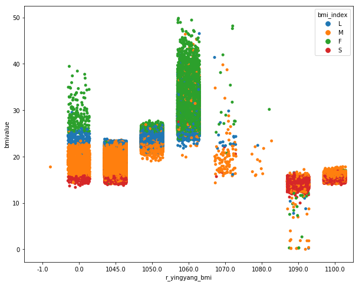

```python
# 假定认为bmi在0-50之间为正确数据
data_comp=data_comp[data_comp['bmivalue']<50][['r_yingyang','r_yingyang_bmi','bmivalue','BMI','bmi_index']]
plt.figure(figsize=(10,8))
sns.stripplot(y='bmivalue',x='r_yingyang_bmi',hue='bmi_index',data=data_comp,jitter=0.3);
```

从上图可以很清楚的看出，对于“营养bmi”测量标准：

1. 肥胖的学生（绿色的点）主要集中在“营养bmi”的中心区域：1060周围;
2. 偏瘦的学生（红色的点）主要集中在“营养bmi”的右侧区域：1090周围；
3. 偏胖的学生（蓝色的点）主要集中在“营养bmi”的左侧区域：0，1050周围；
4. 正常的学生（橙色的点）主要集中在“营养bmi”的左侧区域：0，1045周围。

这说明虽然“营养bmi”的每个取值都存在不同“肥胖程度”的学生，但是在一些特定取值处某类“肥胖程度”的学生数会占据大量比例=〉说明“营养bmi”（r_yingyang_bmi）和“肥胖程度”（BMI）之间虽然没有线性相关关系，但仍存在某种对应联系。

## 九、肥胖，身高，体重，年龄综合分析

这一部分主要对肥胖，身高，体重，年龄进行综合分析，将四个不同的属性表达在一个3D的立体图像中，以此来发现它们四种之间的关系。

```python
from mpl_toolkits.mplot3d import Axes3D
```

首先将四个不同属性的数据提取到一张表中，下表显示了部分数据：

```python
#首先将四个不同属性的数据提取到一张表中
data_ana = data[['BMI','Height','Weight','Age']]
data_ana.head()
```

|  | BMI | Height | Weight | Age |
| --- | --- | --- | --- | --- |
| 0 | L | 161.8 | 61.6 | 13.0 |
| 1 | M | 161.0 | 47.9 | 14.0 |
| 2 | M | 164.5 | 50.2 | 13.0 |
| 3 | F | 166.4 | 82.4 | 13.0 |
| 4 | M | 170.5 | 47.3 | 13.0 |

[output not shown]

```
Text(0.5,0.92,'Scatterplot of Height, Weight and Age')
```

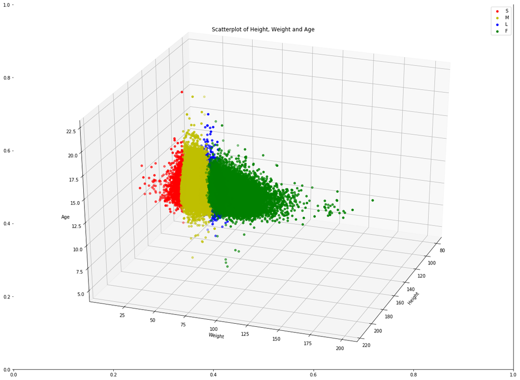

```python
#提取数据，转化为矩阵形式储存
data_ana_matrix=data_ana[['Height','Weight','Age']].as_matrix()
data_ana_assignment = data_ana['BMI'].as_matrix()

#假定认为bmi在0-50之间为正确数据,r_yingyang在960-1060之间为有效数据
colors = ['r','y','b','g']
l=['S','M','L','F']

length=len(data_ana_assignment)
fig, ax = plt.subplots(figsize=(20,15))
ax = fig.add_subplot(111, projection='3d')

for i in range(4):
    points = np.array([data_ana_matrix[j] for j in range(length) if data_ana_assignment[j]==l[i]])
    ax.scatter(xs=points[:,0],ys=points[:,1],zs=points[:,2],color=colors[i],label=l[i])
plt.legend(loc='best')
plt.xlabel('Height')
plt.ylabel('Weight')
ax.set_zlabel('Age')
ax.view_init(elev=30,azim=20)
plt.title('Scatterplot of Height, Weight and Age')
```

从上面的3D图中可以看出：

- “肥胖程度”在“体重”（Weight）属性上明显分层：“偏瘦”的数据（红色）集中在小“体重”数值处，而“肥胖”的数据（绿色）集中在大“体重”数值处；
- 对于其它另外两个属性，“肥胖程度”数据交叠在一起，没有出现明显分层=〉“肥胖程度”与“年龄”（Age）和“身高”（Height）不存在线性相关关系。

以上结论与前几部分的推测和结论相一致。

## 十、PCA 降维（尝试）

由于理解几十个维度的数据结构很困难，两三个维度的数据通过可视化更容易理解。PCA降维可以在压缩数据，尽量在降低信息损失的情况下降低数据的维度。

```python
from sklearn.decomposition import PCA
pca=PCA()
pca.fit_transform(imputed_data_std.iloc[:,1:]);
```

计算每个维度的重要性：（从大到小表示在下表）

```python
explained_variance=pca.explained_variance_
ratio=explained_variance/explained_variance.sum()*100
ratio_table=pd.DataFrame(ratio)
ratio_table=ratio_table.transpose()
ratio_table.index=['Variance Ratio']
ratio_table
```

|  | 0 | 1 | 2 | 3 | 4 | 5 | 6 | 7 | 8 | 9 | ... | 21 | 22 | 23 | 24 | 25 | 26 | 27 | 28 | 29 | 30 |
| --- | --- | --- | --- | --- | --- | --- | --- | --- | --- | --- | --- | --- | --- | --- | --- | --- | --- | --- | --- | --- | --- |
| Variance Ratio | 12.487501 | 9.833147 | 6.081215 | 5.016601 | 4.49343 | 3.903364 | 3.730428 | 3.640297 | 3.511038 | 3.352728 | ... | 2.056779 | 1.911753 | 1.589381 | 1.362642 | 1.277878 | 1.168741 | 0.875358 | 0.715041 | 0.638041 | 0.20202 |

1 rows × 31 columns

```python
covariance=pca.get_covariance() #covariance
```

通过柱状图更清晰的展示每个维度的重要性：（从大到小）

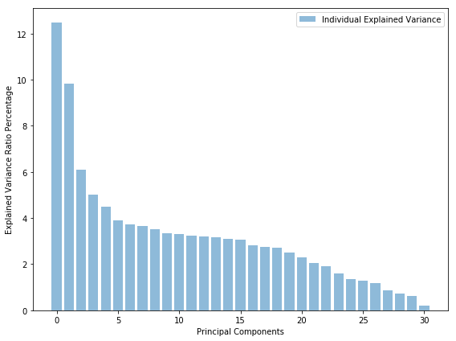

```python
fig2=plt.figure(figsize=(8,6))
plt.bar(range(31), ratio, alpha=0.5, align='center', label='Individual Explained Variance')
plt.ylabel('Explained Variance Ratio Percentage')
plt.xlabel('Principal Components')
plt.legend(loc='best')
plt.tight_layout()
```

```python
# 把所有数据降到二维
pca_modified=PCA(n_components=2)
data_pca=pca_modified.fit_transform(imputed_data_std.iloc[:,1:])
#转换成表格形式并加入对应的“肥胖程度”属性
pd_pca=pd.DataFrame(data_pca)
pd_pca['BMI']=data_comp['BMI']
pd_pca.columns=['dimension1','dimension2','BMI']
pd_pca=pd_pca.dropna(axis=0, how='any')
```

将所有数据降至二维，观察不同“肥胖程度”的数据在此二维空间中的分布，如下图所示：

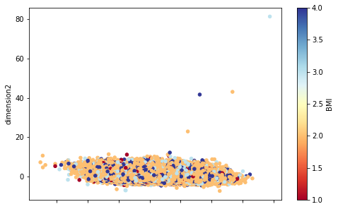

```python
# 根据不同的BMI数值做出散点图
pd_pca.plot.scatter(y='dimension2',x='dimension1',c='BMI',colormap='RdYlBu',figsize=(8,5));
```

观察上图：

- 大部分数据集中在一起，且无明显的分类状况发生；
- 有一点出现在右上角，通过点的颜色可知“肥胖程度”为“偏胖”
- 在偏右上侧有三个分离集体的点，通过点的颜色可知“肥胖程度”为“肥胖”和“正常”
- 在左侧有部分点偏离集体，通过点的颜色可知“肥胖程度”为“正常”